# KHELID Lilya-Nada

# Utilisation de R pour le PMC (Perceptron Multicouche)

## Qu’est-ce qu’un PMC ?

Un perceptron multicouche (PMC) est un modèle de réseau de neurones artificiels conçu pour résoudre des problèmes complexes comme la classification et la régression. Il comprend trois types principaux de couches :

1. **Couche d’entrée :** reçoit les données brutes.
2. **Couches cachées :** appliquent des transformations via des poids et des fonctions d’activation.
3. **Couche de sortie :** fournit les prédictions ou classifications finales.

### Fonctionnement

Le PMC fonctionne en suivant ces étapes principales :

1. **Propagation avant :** Les données traversent les couches pour produire une sortie.
2. **Calcul de l’erreur :** On mesure l’écart entre la sortie prédite et la sortie attendue à l’aide d’une fonction de perte.
3. **Rétropropagation :** L’erreur est propagée en arrière pour ajuster les poids.
4. **Mise à jour des poids :** Les poids sont modifiés pour minimiser l’erreur.

La mise à jour des poids suit la formule :

$$\Delta w_{ij} = -\eta \frac{\partial E}{\partial w_{ij}}$$

où $\eta$ est le taux d’apprentissage et $\frac{\partial E}{\partial w_{ij}}$ est le gradient de l’erreur par rapport au poids.

### Fonctions d’activation

Les fonctions d’activation introduisent de la non-linéarité dans le modèle, permettant au réseau de modéliser des relations complexes. Les plus courantes sont :

- **Sigmoïde logarithmique :**
  $$f(x) = \frac{1}{1 + e^{-x}}$$
- **Tangente hyperbolique :**
  $$f(x) = \tanh(x)$$
- **ReLU (Rectified Linear Unit) :**
  $$f(x) = \max(0, x)$$

### Utilisation en R

Nous nous servirons de la librairie `nnet` tres utils en R.

```r
options(repos = c(CRAN = "https://cran.rstudio.com/"))
```

```r
library(nnet)
# --sin--
x <- sort(10 * runif(50))
y <- sin(x) + 0.2 * rnorm(length(x))
data <- data.frame(x, y)

#--PMC--
nn <- nnet(x, y, size = 4, maxit = 100, linout = TRUE)
```

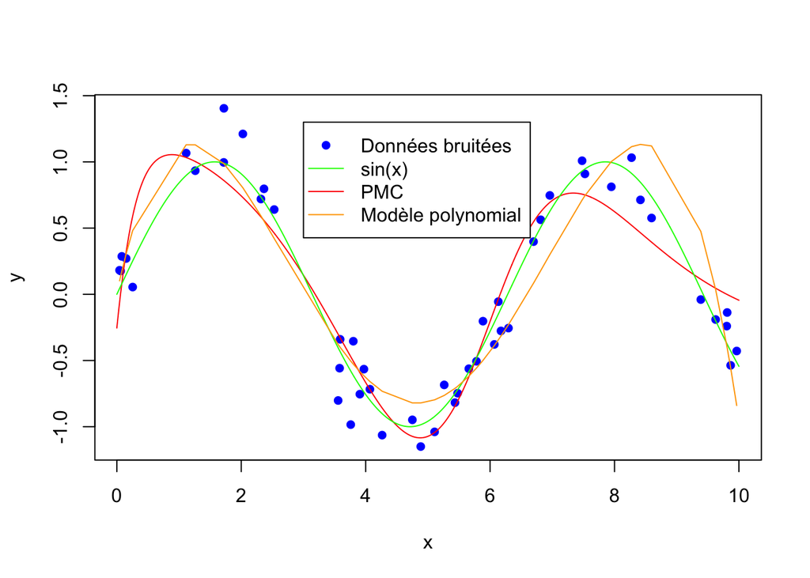

```r
plot(x, y, col = "blue", pch = 16)
x1 <- seq(0, 10, by = 0.01)
lines(x1, predict(nn, data.frame(x = x1)), col = "red")
lines(x1, sin(x1), col = "green")

#--Comparaison avec un modèle polynomial--
modelPoly <- lm(y ~ x + I(x^2) + I(x^3) + I(x^4))
lines(x, predict(modelPoly), col = "orange")
legend(3, 1.3, c("Données bruitées", "sin(x)", "PMC", "Modèle polynomial"),
       lty = c(0, 1, 1, 1), pch = c(16, -1, -1, -1), col = c("blue", "green", "red", "orange"))
```

Ce code montre comment utiliser un PMC pour approximer une fonction continue en utilisant des données bruitées et comparer les prédictions avec les valeurs réelles.

## Classification de données catégoriques : exemple avec `Titanic`

Un autre exemple courant consiste à entraîner un PMC pour classifier des données multivariées, comme l’ensemble `Titanic`. Le modèle est évalué à l’aide d’une matrice de confusion.

```r
install.packages("titanic")
library(titanic)

data("titanic_train")

titanic <- titanic_train[, c("Survived", "Pclass", "Sex", "Age", "SibSp", "Parch", "Fare", "Embarked")]

#--valeurs manquantes--
titanic$Age[is.na(titanic$Age)] <- mean(titanic$Age, na.rm = TRUE)
titanic$Embarked[is.na(titanic$Embarked)] <- "S"

#--mettre des niveaux--
titanic$Survived <- as.factor(titanic$Survived)
titanic$Pclass <- as.factor(titanic$Pclass)
titanic$Sex <- as.factor(titanic$Sex)
titanic$Embarked <- as.factor(titanic$Embarked)

#--split en test et train--
set.seed(123)
train_index <- sample(1:nrow(titanic), size = 0.7 * nrow(titanic))
train_data <- titanic[train_index, ]
test_data <- titanic[-train_index, ]

#--PMC--
model <- nnet(Survived ~ Pclass + Sex + Age + SibSp + Parch + Fare + Embarked,
              data = train_data, size = 5, decay = 0.01, maxit = 200)
summary(model)
```

```
## a 10-5-1 network with 61 weights
## options were - entropy fitting  decay=0.01
##   b->h1  i1->h1  i2->h1  i3->h1  i4->h1  i5->h1  i6->h1  i7->h1  i8->h1  i9->h1
##    6.29   -6.17    0.35   -3.63   -0.61   -0.83    0.59    1.03    6.83   -0.18
## i10->h1
##   -0.36
##   b->h2  i1->h2  i2->h2  i3->h2  i4->h2  i5->h2  i6->h2  i7->h2  i8->h2  i9->h2
##   -2.46    1.39   -3.77   -2.90   -0.77   -0.93   -6.16    2.51   -1.88   -1.84
## i10->h2
##    1.24
##   b->h3  i1->h3  i2->h3  i3->h3  i4->h3  i5->h3  i6->h3  i7->h3  i8->h3  i9->h3
##   -4.81    1.58    6.14    5.69    0.02    0.10    0.53    0.01   -1.38   -2.47
## i10->h3
##   -0.99
##   b->h4  i1->h4  i2->h4  i3->h4  i4->h4  i5->h4  i6->h4  i7->h4  i8->h4  i9->h4
##    2.48   -1.35    0.73   -1.49    0.65    0.01   -0.01   -3.99    1.94    2.61
## i10->h4
##   -2.08
##   b->h5  i1->h5  i2->h5  i3->h5  i4->h5  i5->h5  i6->h5  i7->h5  i8->h5  i9->h5
##   -1.78    1.61    1.85    5.96   -1.06   -2.46    2.84    0.06    1.23    0.05
## i10->h5
##   -3.05
##  b->o h1->o h2->o h3->o h4->o h5->o
##  3.95  2.11 -2.05 -6.05 -5.04  8.09
```

```r
predictions <- predict(model, test_data, type = "class")

#--Confusion matrix--
conf_matrix <- table(Predicted = predictions, Actual = test_data$Survived)
print(conf_matrix)
```

```
##          Actual
## Predicted   0   1
##         0 149  32
##         1  19  68
```

```r
accuracy <- sum(diag(conf_matrix)) / sum(conf_matrix)
print(paste("Précision :", round(accuracy * 100, 2), "%"))
```

```
## [1] "Précision : 80.97 %"
```

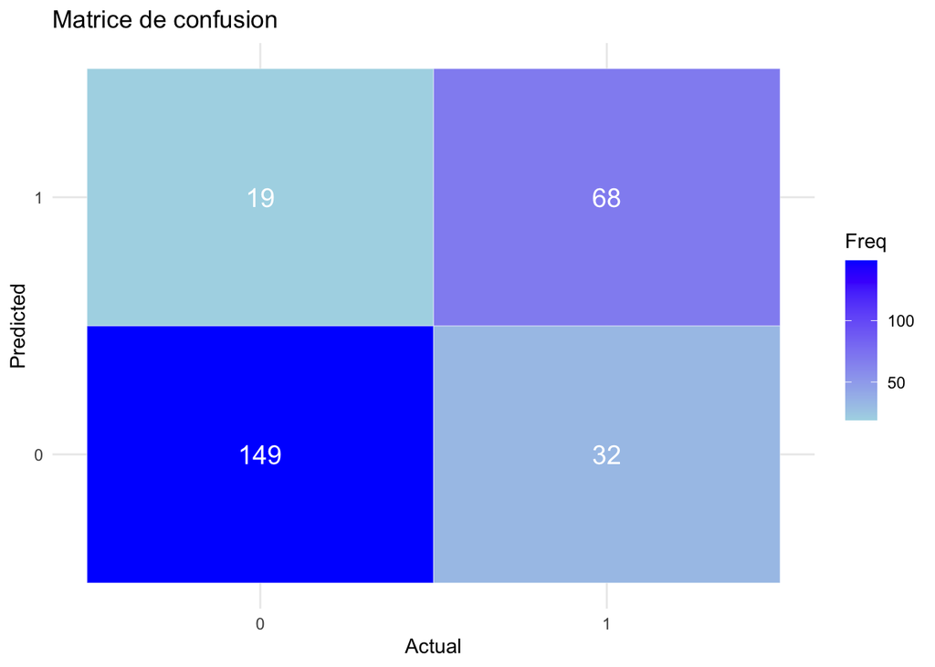

```r
library(ggplot2)

conf_matrix <- as.data.frame(table(Predicted = predictions, Actual = test_data$Survived))

ggplot(conf_matrix, aes(x = Actual, y = Predicted, fill = Freq)) +
  geom_tile(color = "white") +
  scale_fill_gradient(low = "lightblue", high = "blue") +
  geom_text(aes(label = Freq), color = "white", size = 5) +
  labs(title = "Matrice de confusion", x = "Actual", y = "Predicted") +
  theme_minimal()
```

## Ajustement des hyperparamètres avec `tune.nnet`

Pour optimiser les performances du PMC, nous utilisons une recherche par validation croisée pour ajuster les paramètres comme `size` (nombre de neurones dans la couche cachée) et `decay` (régularisation). Voici un exemple de code en R :

```r
library(e1071)

#--tunning--
tune.model <- tune.nnet(Survived ~ Pclass + Sex + Age + SibSp + Parch + Fare + Embarked,
                         data = train_data, size = c(3, 5, 7), decay = c(0.001, 0.01, 0.1))
print(tune.model)
```

```
##
## Parameter tuning of 'nnet':
##
## - sampling method: 10-fold cross validation
##
## - best parameters:
##  size decay
##     7  0.01
##
## - best performance: 0.1865899
```

```r
best_model <- nnet(Survived ~ Pclass + Sex + Age + SibSp + Parch + Fare + Embarked,
                   data = train_data, size = tune.model$best.parameters$size,
                   decay = tune.model$best.parameters$decay, maxit = 200)
final_predictions <- predict(best_model, test_data, type = "class")
final_conf_matrix <- table(Predicted = final_predictions, Actual = test_data$Survived)
final_accuracy <- sum(diag(final_conf_matrix)) / sum(final_conf_matrix)

print(final_conf_matrix)
```

```
##          Actual
## Predicted   0   1
##         0 145  33
##         1  23  67
```

```r
print(paste("Précision optimisée :", round(final_accuracy * 100, 2), "%"))
```

```
## [1] "Précision optimisée : 79.1 %"
```

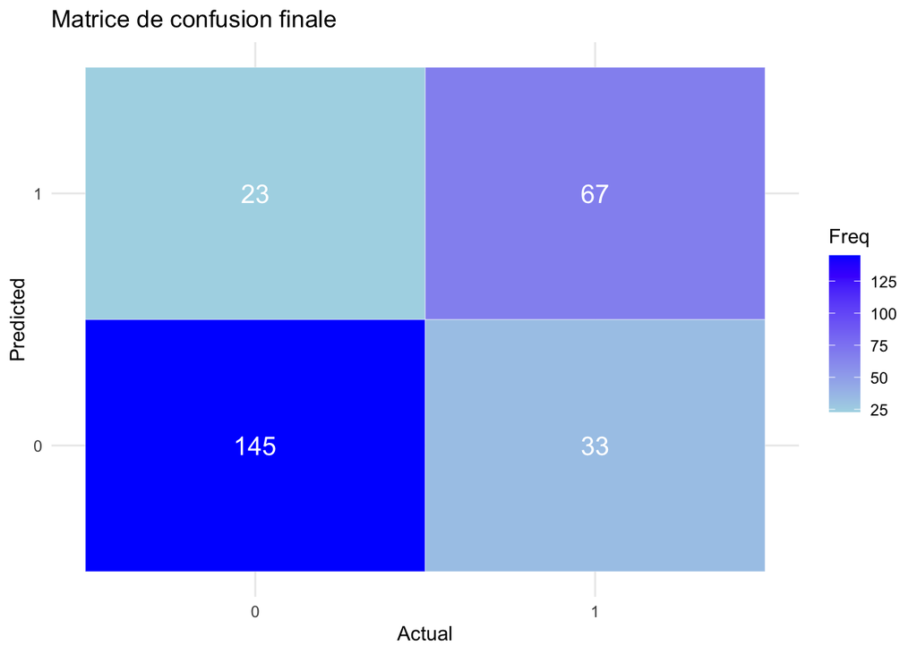

```r
final_conf_matrix_df <- as.data.frame(final_conf_matrix)
ggplot(final_conf_matrix_df, aes(x = Actual, y = Predicted, fill = Freq)) +
  geom_tile(color = "white") +
  scale_fill_gradient(low = "lightblue", high = "blue") +
  geom_text(aes(label = Freq), color = "white", size = 5) +
  labs(title = "Matrice de confusion finale", x = "Actual", y = "Predicted") +
  theme_minimal()
```